# Data science capstone presentation

RH  
03/19/2017

This presentation aims at pitching the [shinyapp](https://kentryo.shinyapps.io/next_word_prediction/) for next-word prediction application.

This presentation is part of the work for the Coursera Data Science Capstone course.

### Objectives

The overall goal of this project is to build a shinyapp for predicting the next word and to make a product presentation to demonstrate the algorithm and and application instruction.

Specific goals are listed below:

- Analyze the [raw data](https://d396qusza40orc.cloudfront.net/dsscapstone/dataset/Coursera-SwiftKey.zip)
- Analyze the N-gram patterns and summarize
- Build a predictive model using backoff algorithm
- Improve the application for prediction

### Algorithm

In general, this application used n-gram patterns and backoff algorithm for prediction.

N-gram description is as: In the fields of computational linguistics and probability, an n-gram is a contiguous sequence of n items from a given sequence of text or speech. The items can be phonemes, syllables, letters, words or base pairs according to the application. The n-grams typically are collected from a text or speech corpus.

[Katz's back-off model](https://en.wikipedia.org/wiki/Katz's_back-off_model) is used for this application with some simplification. Katz back-off is a generative n-gram language model that estimates the conditional probability of a word given its history in the n-gram. It accomplishes this estimation by “backing-off” to models with smaller histories under certain conditions. By doing so, the model with the most reliable information about a given history is used to provide the better results.

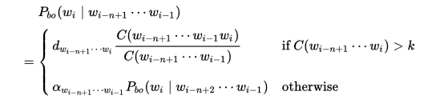

### Application instruction

This application is aimed at predicting next-word using n-gram words analysis and simple backoff prediction methods.

Put a partial sentence or several words in the word-input and this application will predict the next-word based on the n-gram words analysis showing on the right side.

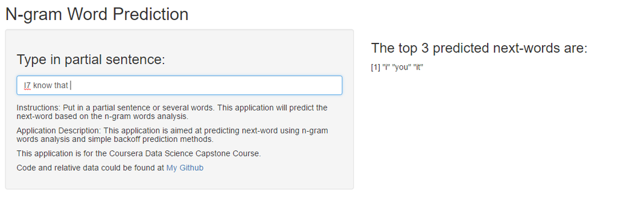

### Summary and relative sources

This project is for the work for the Coursera Data Science Capstone course.

The shinyapp is hosted at: https://kentryo.shinyapps.io/next_word_prediction/

The relative code could be found at: https://github.com/kentryo/data-science-capstone

The course info is at: https://www.coursera.org/learn/data-science-project/home/welcome